# What is the R t value?”

The R value, also known as the reproduction number, describes how many people an infected person infects on average. Together with the number of new infections every day, the time-dependent reproduction number R t is an important measure of how quickly the disease is currently spreading. There are three cases:

R t > 1: the number of new infections increases R t = 1: the number of new infections remains the same R t <1: the number of new infections decreases

As the COVID-19 pandemic already continuing in Bangladesh, despite no nation-wide lockdown in place, schools, college, universities remained close till now, it is important to watch daily Rt for Bangladesh to set up comprehensive strategies by policy-makers.

# Last Updated 18-08-2020

# Model 1:

Paper Hridoy et al. (2020): https://www.medrxiv.org/content/10.1101/2020.08.04.20168351v1.full.pdf+html

Assumption

Serial Interval:the time between the start of symptoms in the primary patient (infector) and onset of symptoms in the patient receiving that infection from the infector (the infectee).

We assumed that the serial interval was uncertain with a mean of 3.96 days and a standard deviation of 4.75 days according to recent findings by Du et al(2020)

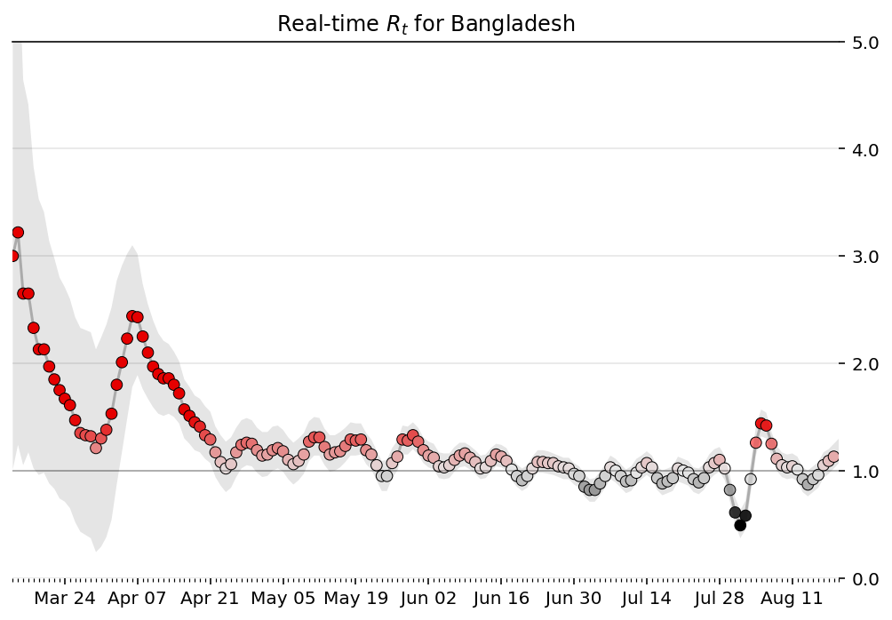

Last 10 days Rt estimates for Bangladesh,where ML is the most likely value ,and Low_90 and High_90 is 90% confidence interval.

| Date | ML | Low_90 | High_90 |
| --- | --- | --- | --- |
| 2020-08-10 | 1.03 | 0.92 | 1.15 |
| 2020-08-11 | 1.04 | 0.93 | 1.16 |
| 2020-08-12 | 1.01 | 0.90 | 1.13 |
| 2020-08-13 | 0.92 | 0.80 | 1.03 |
| 2020-08-14 | 0.87 | 0.76 | 1.00 |
| 2020-08-15 | 0.92 | 0.80 | 1.04 |
| 2020-08-16 | 0.96 | 0.84 | 1.08 |
| 2020-08-17 | 1.05 | 0.93 | 1.17 |
| 2020-08-18 | 1.09 | 0.97 | 1.20 |
| 2020-08-19 | 1.13 | 1.02 | 1.25 |

The most recent 𝑅𝑡 as of 2020-08-19 for COVID-19 in Bangladesh is 1.1300000000000001 ,meaning, on average each infected person has been spreading the infection to 1.1300000000000001 others.

As of now the mean 𝑅𝑡 for COVID-19 in Bangladesh is 1.26 ,meaning, on average each infected person has been spreading the infection to 1.26 others.In other words, that infected people have spread the virus to an average of one other person, with 0.26 added chance of infecting a second individual.

# Second Model

According to a recent paper "Practical considerations for measuring the effective reproductive number, Rt"(June,2020) Gostic et al.(2020)[1] reported that Adapted Bettencourt and Ribeiro (2008)[2] methods(Which is our first method), may be biased if the underlying structural assumptions are not met, since it depends on many parameters.The author recommend the approach of Cori et al. (2013).In addition the method of Thompson et al. (2019) has been using by Imperial college London to estimates Rt worldwide(https://www.nature.com/articles/s41586-020-2405-7 ) , also by (https://epiforecasts.io/covid ).

Addressing the limitation of our first model, the author also considered to use the methods of Cori et al .(2013) to estimate daily reproduction number for COVID-19 in Bangladesh.

In addition, Rt estimation for Bangladesh (https://epiforecasts.io/covid/posts/national/bangladesh/) do not provide daily Rt estimation,they are at least 10 days behind, thus given the urgency of COVID-19 situation in Bangladesh , author is inspired to estimate daily real-time Rt for COVID-19 in Bangladesh.

References:

[1] https://www.ncbi.nlm.nih.gov/pmc/articles/PMC7325187/

[2] https://journals.plos.org/plosone/article?id=10.1371/journal.pone.0002185

# Methods

We used the inferred number of cases to estimate the reproduction number on each day using the EpiEstim v.2 R package[1] and later extened by Thompson et al [2] . This uses a combination of the serial interval distribution and the number of observed cases to estimate the reproduction number at each time point [2,3], which were then smoothed using a 7-day time window. We assumed that the serial interval was uncertain with a mean of 3.96 days and a standard deviation of 4.75 days according to recent findings bu Du et al[4] . We used a common prior for the reproduction number with mean 2.6 and a standard deviation of 2 (inflated from 0.5 found in the reference)[5] .We used smoothed( 7 day moving average) daily new cases.

References

[1] Cori A, Ferguson NM, Fraser C et al. A New Framework and Software to Estimate Time-Varying Reproduction Numbers During Epidemics. American Journal of Epidemiology 2013;178:1505–12. doi:10.1093/aje/kwt133

[2]Thompson RN, Stockwin JE, van Gaalen RD, Polonsky JA, et al. Improved inference of time-varying reproduction numbers during infectious disease outbreaks. Epidemics (2019).

[3] Wallinga J, Teunis P. Different Epidemic Curves for Severe Acute Respiratory Syndrome Reveal Similar Impacts of Control Measures. American Journal of Epidemiology 2004;160:509–16. doi:10.1093/aje/kwh255 [4]Serial Interval of COVID-19 among Publicly Reported Confirmed Cases  
[5] Imai N, Cori A, Dorigatti I et al. Report 3: Transmissibility of 2019-nCoV. https://www.imperial.ac.uk/media/imperial-college/medicine/sph/ide/gida-fellowships/Imperial-2019-nCoV-transmissibility.pdf

# Daily real-time Rt estimation according to Thompson et al. (2019)

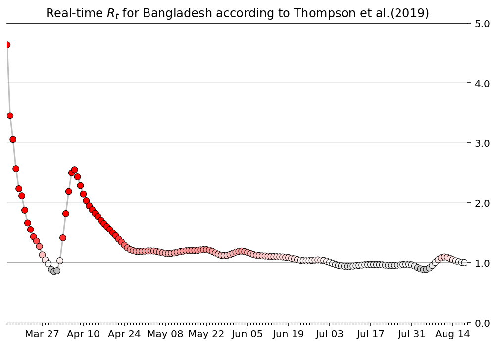

# Rt estimation for last 10 days

| date | Rt_mean | low_ci_05 | high_ci_95 |
| --- | --- | --- | --- |
| 2020-08-09 | 1.048962 | 1.035759 | 1.062235 |
| 2020-08-10 | 1.080591 | 1.067346 | 1.093906 |
| 2020-08-11 | 1.093544 | 1.080421 | 1.106734 |
| 2020-08-12 | 1.088810 | 1.075921 | 1.101764 |
| 2020-08-13 | 1.070197 | 1.057590 | 1.082866 |
| 2020-08-14 | 1.047635 | 1.035280 | 1.060051 |
| 2020-08-15 | 1.028639 | 1.016463 | 1.040876 |
| 2020-08-16 | 1.013829 | 1.001767 | 1.025951 |
| 2020-08-17 | 1.004751 | 0.992745 | 1.016818 |
| 2020-08-18 | 0.999850 | 0.987862 | 1.011898 |

The most recent 𝑅𝑡 as of 2020-08-19 for COVID-19 in Bangladesh is 1.0 ,meaning, on average each infected person has been spreading the infection to 1.0 others.

As of 2020-08-19 the mean 𝑅𝑡 for COVID-19 in Bangladesh is 1.27 ,meaning, on average each infected person has been spreading the infection to 1.27 others.In other words, that infected people have spread the virus to an average of one other person, with 0.27 added chance of infecting a second individual.

# Limitation

The model face limitations associated with data uncertainties such as differences in testing, inconsistent, delayed reporting, and low number cases, and high variability. The results are impacted by testing rate, increases and decreases in testing rate will increase and decrease reproduction number estimates, respectively.

While author made best effort to accurately describe Rt, nothing can do that perfectly. Please calibrate with other sources, like https://epiforecasts.io/covid/posts/national/bangladesh/, as well.

# LOW TEST ? How Many People Actually Have COVID-19 ?

# Test adjusted Rt estimation

To address the of limitation of testing effort on true case, the author also used daily smoothed positive rate to estimate true actual case and Rt.

1.Generalized Methods: Equation 1: y=m*x*q^k+ϵ

where,

y is the true cases

x is the confirmed new cases/observed new cases

m is an unknown constant multiplier of x

q is the test positivity rate k is an unknown constant exponent of q, between zero and one. ϵ is a random error term of unknown distribution

The underlying idea is when testing increases, test positivity gets lowerer.Observed new cases and test positivity were smoothed(7 day rollling averaged). The m and k value is obtained from basic curve fitting.

Disclaimer: This method is hugely inspired from here (http://freerangestats.info/blog/2020/05/09/covid-population-incidence) ,

Similiar method can also be found at ( https://covid19-projections.com/estimating-true-infections/ )

Limitation: Taking test positivity rates as a proxy for estimate true cases may lead to better estimates of growth and of effective reproduction number. But it can’t work miracles - we don’t know how to calibrate it so it’s not going to be good for estimating the absolute value. And we still can’t get reliable estimates of growth or effective reproduction number when the data just aren’t there to support it.

# Estimated true daily COVID-19 cases in Bangladesh

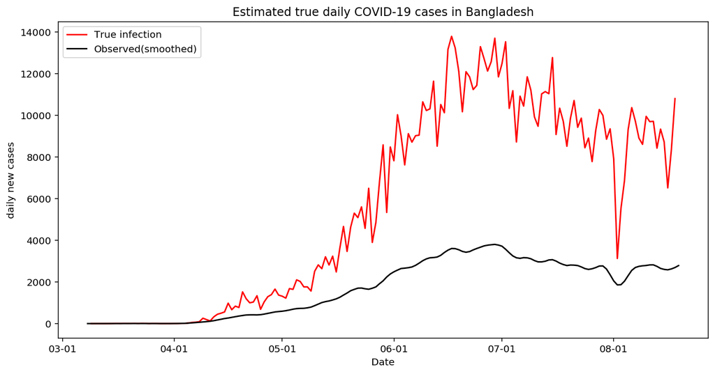

Is this a reasonable estimate?

CDC[1] reported that Actual Covid-19 case count could be 6 to 24 times higher than official estimates.

we considered a maximum prevalence ratio of 6 in response to test positivity in Bangladesh,assuming a good case scenario.

[1] : https://www.statnews.com/2020/07/21/cdc-study-actual-covid-19-cases/

# How much testing is needed per day in Bangladesh

To answer this question, we assume 40% asymptomatic and each symptomatic individual(true daily infection) testing positive for COVID-19 will have on average 10 contacts who will need to be tested[1].

[1] : https://globalepidemics.org/2020/05/10/modeling-uncertainty-how-to-make-sense-of-changing-predictions/

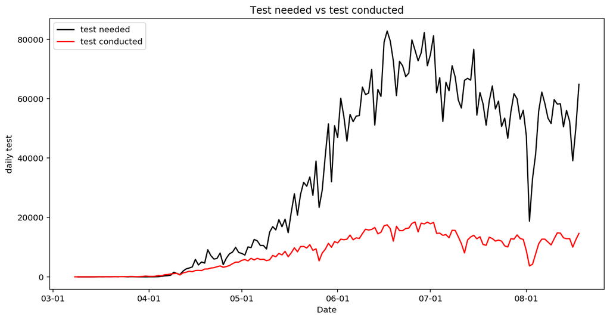

# Test Adjusted Rt estimation using Generalized Method

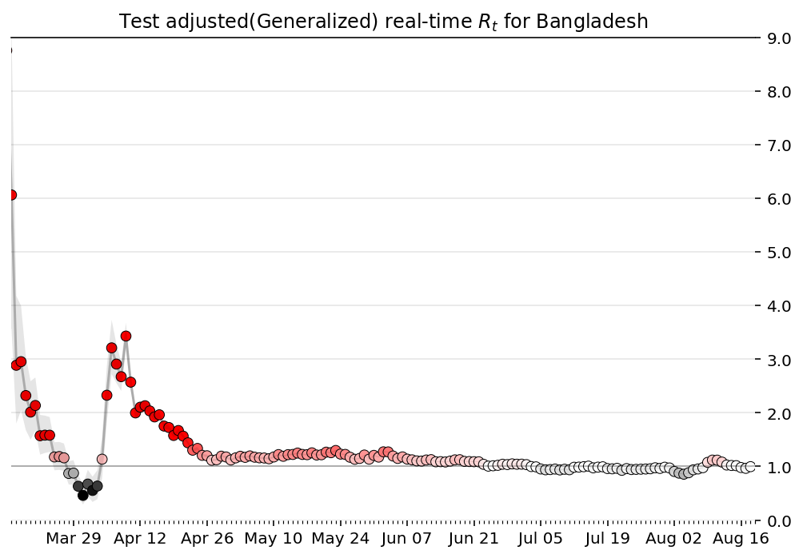

# Test adjusted Rt estimation for last 10 days

| date | Rt_mean | low_ci_05 | high_ci_95 |
| --- | --- | --- | --- |
| 2020-08-09 | 1.076142 | 1.068886 | 1.083419 |
| 2020-08-10 | 1.118632 | 1.111357 | 1.125928 |
| 2020-08-11 | 1.117659 | 1.110544 | 1.124792 |
| 2020-08-12 | 1.081813 | 1.074947 | 1.088697 |
| 2020-08-13 | 1.026654 | 1.020042 | 1.033285 |
| 2020-08-14 | 1.018228 | 1.011650 | 1.024823 |
| 2020-08-15 | 1.014623 | 1.008059 | 1.021204 |
| 2020-08-16 | 0.980384 | 0.973937 | 0.986850 |
| 2020-08-17 | 0.964941 | 0.958512 | 0.971388 |
| 2020-08-18 | 0.996609 | 0.990029 | 1.003208 |

The most recent 𝑅𝑡 as of Test adjusted(Generelized) for COVID-19 in Bangladesh is 1.0 ,meaning, on average each infected person has been spreading the infection to 1.0 others.

# Recommendation

1.Broader testing 2. And a careful calibration of measures to keep Rt a long way below the crucial threshold one.Unless Bangladesh will be flying blind in the course of pandemic.

# Funding

Given the urgency of COVID-19 situation in Bangladesh, this is the first attempt to estimate daily real-time Rt,true new infections,number of tests needed to conduct for COVID-19 in Bangladesh for the greater good.

No public funding has been received, making us a completely independent entity.

# Contact

Al-Iqram Elahee Hridoy(University of Chittagong, mail: aliqramalaheehridoy@gmail.com,

FB: https://web.facebook.com/hridoy.all )

```
[NbConvertApp] Converting notebook index.ipynb to html
[NbConvertApp] Writing 859276 bytes to index.html
```